**An Analysis of Hate Crimes and Social Media**

**By Nicholas Aoki, Jayoung Kim, and Elizabeth Steinbach (Group 2)**

# 1. Introduction

Hate crimes, or "crime[s] motivated by bias against race, religion, national origin, sexual orientation, gender, gender identity, or disability" [1] have been rising in the United States [2, 3]. Given this increase in hate crimes, analyzing hate crime data and assessing how other factors, such as political affiliation and social media usage, may contribute to the problem are important as they may inform policymakers about how to mitigate this rise in hate crimes.

There are three overarching goals of this study: (a) to conduct an exploratory data analysis on hate crime data to better understand how the nature and target of hate crimes have changed over time; (b) to test whether political affiliation is related to the geographical distribution of hate crimes; (c) to analyze social media posts using natural language processing techniques in order to figure out the connections between hateful rhetoric online and hate crimes.

To narrow the scope of our analysis, we will specifically be investigating hate crimes in California from 2001 to 2020. Our specific questions are as follows:

1. How have the number of hate crimes changed over time?
2. Which types of hate crimes are the most common? How have the types of hate crimes changed over time?
3. Which racial and religious groups tend to be the most targeted?
4. How is county political affiliation related to the geographical distribution of hate crimes?
5. How does the distribution of the types of hateful social media posts compare to the types of hate crimes?

This report is structured as follows. There are five parts after the Introduction. The first part ("Results: Exploratory Data Analysis") contains responses to the first three questions (1, 2, 3). The second part ("Results: Political Affiliation and Hate Crimes") answers Question 4, and the third part ("Results: Social Media Posts") responds to Question 5. Each of these three parts are further divided into subsections, and a description of these subsections is provided at the beginning of each part. The fourth part discusses the limitations of this study and offers a conclusion where a summary of the major findings can be found. The fifth part includes the references.

The analysis in this report draws on the topics covered in the lectures from the "Week_1-1" notebook to the "Week_3-2" notebook as well as the lectures from the natural language processing unit ("Week_6-1" to "Week_7-1"). In terms of extra credit, we have (a) employed statistical analysis by conducting a correlational analysis (see "Results: Political Affiliation and Hate Crimes"); (b) employed GeoPandas, a package that was not covered in class, to visualize the geographical distribution of hate crimes (see "Results: Political Affiliation and Hate Crimes"), and (c) used multiple data sets to answer the research questions. More specifically, we have employed eight data sets with the following information: (1) hate crimes in California from 2001 to 2020; (2) metadata with number of each county; (3) population data from California from 2000 to 2009; (4) population data from California from 2010 to 2019; (5) a shapefile with California county boundaries; (6) voter registration data for California counties in 2008; (7) voter registration data for California counties in 2016; (8) social media posts from Stormfront, a right-wing social media site. All of these data sets are reputable (i.e., they are all either from government sources or from journal articles). The contents of each data set are described in more detail in the section where they are first employed. Links to all data sets can be found in the "References" section.

# 2. Results: Exploratory Data Analysis

This section is subdivided into four parts. In the first part, the hate crimes data set is inspected and described. The next three parts answer the first three questions in the Introduction in order: (1) How have the number of hate crimes changed over time?; (2) Which types of hate crimes are the most common? How have the types of hate crimes changed over time?; (3) Which racial and religious groups tend to be the most targeted?.

## 2.1 Inspecting the Hate Crimes Data Set

The hate crimes data set comes from the data portal of the State of California Department of Justice [4]. The data set has 24436 rows and 23 columns (Block 2), where each row corresponds to a unique hate crime committed in California from 2001 to 2020. The column names (shown in Block 3) include information about each crime. The specific columns that will be used in this report ("ClosedYear", "County", "MostSeriousBiasType", and "MostSeriousBias") are shown in Block 4. The first two columns, "ClosedYear" and "County", indicate the year when the crime occurred and the county where the crime occurrred. The third column, "MostSeriousBiasType", classifies the crimes in terms of broad categories about the motivation of the crimes (e.g., whether the crime was committed because of a bias against a particular race/ethnicity/ancestry or against a particular sexual orientation, etc.). The fourth column, "MostSeriousBias", provides more detail about the specific social group that was targeted. For example, among the crimes committed because of a bias against race/ethnicity/ancestry, was the targeted social group Black or Hispanic?

Although we have narrowed the scope of our analysis to these four columns, we note that there are other aspects of the hate crimes in the data set that could also be explored (e.g., "MonthOccurrence" contains the month when the hate crimes occurred). We leave this analysis for future research.

Before moving on to the rest of the exploratory data analysis, the types of the columns were examined (Block 5). The type of the "ClosedYear" column was changed from "int64" to "object" (Block 6) so that the hate crimes could be grouped by year.

```python
# These packages will be used for the hate crimes data set.
import pandas as pd
import numpy as np
import geopandas as gpd
import matplotlib.pyplot as plt
import descartes
from matplotlib.pyplot import figure
plt.style.use('fivethirtyeight')
import itertools
from itertools import product
from scipy import stats

# These packages will be used for the natural language processing section.
import os
import glob
import nltk.corpus
import re
import nltk
nltk.download('punkt')
nltk.download('wordnet')
nltk.download('averaged_perceptron_tagger')
from nltk.corpus import wordnet
nltk.download("stopwords")
```

```
True
```

```python
# Download the hate crimes data set and find the number of rows and columns
hate_data = pd.read_csv("~/Downloads/Hate-2001-2020.csv")
hate_data.shape
```

```
(24436, 23)
```

```python
# Display the column names
hate_data.columns
```

```
Index(['RecordId', 'ClosedYear', 'MonthOccurrence', 'County', 'NCIC',
       'TotalNumberOfVictims', 'TotalNumberOfIndividualVictims',
       'SuspectsRaceAsAGroup', 'TotalNumberOfSuspects', 'MostSeriousUcr',
       'MostSeriousUcrType', 'MostSeriousLocation', 'MostSeriousBias',
       'MostSeriousBiasType', 'MostSeriousVictimType', 'WeaponType',
       'Offensive_Act', 'IsMultipleBias',
       'TotalNumberOfIndividualVictimsAdult',
       'TotalNumberOfIndividualVictimsJuvenile', 'TotalNumberOfSuspectsAdult',
       'TotalNumberOfSuspectsJuvenile', 'SuspectsEthnicityAsAGroup'],
      dtype='object')
```

```python
# Inspect the columns of the data set that will be used in this report
hate_data.loc[:,['ClosedYear', 'County', 'MostSeriousBiasType', 'MostSeriousBias']].head()
```

|  | ClosedYear | County | MostSeriousBiasType | MostSeriousBias |
| --- | --- | --- | --- | --- |
| 0 | 2001 | 1 | Race/Ethnicity/Ancestry | Anti-Black or African American |
| 1 | 2001 | 1 | Race/Ethnicity/Ancestry | Anti-Black or African American |
| 2 | 2001 | 1 | Race/Ethnicity/Ancestry | Anti-Hispanic or Latino |
| 3 | 2001 | 1 | Race/Ethnicity/Ancestry | Anti-Hispanic or Latino |
| 4 | 2001 | 1 | Race/Ethnicity/Ancestry | Anti-Other Race/Ethnicity/Ancestry |

```python
# Display the types of the columns of interest
hate_data.loc[:,['RecordId', 'ClosedYear', 'County', 'MostSeriousBiasType', 'MostSeriousBias']].dtypes
```

```
RecordId               object
ClosedYear              int64
County                  int64
MostSeriousBiasType    object
MostSeriousBias        object
dtype: object
```

```python
# Change the type of the "ClosedYear" column
hate_data['ClosedYear'] = hate_data['ClosedYear'].apply(str)
hate_data.loc[:,['RecordId', 'ClosedYear', 'County', 'MostSeriousBiasType', 'MostSeriousBias']].dtypes
```

```
RecordId               object
ClosedYear             object
County                  int64
MostSeriousBiasType    object
MostSeriousBias        object
dtype: object
```

## 2.2 How have the number of hate crimes changed over time?

The first step of the exploratory analysis was to visualize how the number of hate crimes has changed over time in California from 2001 to 2020. The code in Block 7 groups the data by year and tabulates the number of crimes in each year, while Block 8 visualizes the data. The number of hate crimes was at its peak in 2001. Although the number of crimes steadily dropped from 2001 to 2014, the number of crimes increased from 2014 to 2020. Therefore, hate crimes have become a more pressing issue in California as of late (although the number of hate crimes in 2020 is still much lower than that in 2001).

```python
# Group the crimes by year and find the number of crimes per year
hate_by_year = pd.DataFrame(hate_data.groupby('ClosedYear').size())
hate_by_year = hate_by_year.reset_index()
hate_by_year = hate_by_year.set_axis(['Year', 'Total_Hate_Crimes'], axis=1, inplace=False)
hate_by_year.head()
```

|  | Year | Total_Hate_Crimes |
| --- | --- | --- |
| 0 | 2001 | 2261 |
| 1 | 2002 | 1659 |
| 2 | 2003 | 1491 |
| 3 | 2004 | 1409 |
| 4 | 2005 | 1397 |

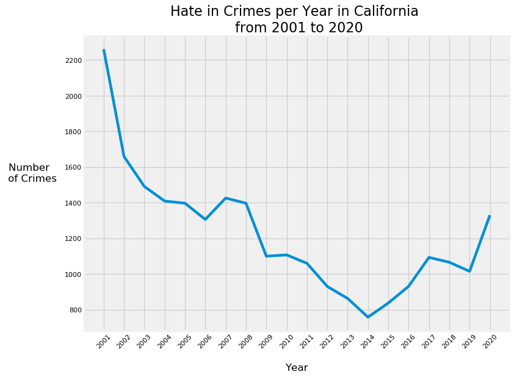

```python
# Plot the number of hate crimes per year
figure(figsize=(10, 8), dpi=80)
plt.plot(hate_by_year['Year'], hate_by_year['Total_Hate_Crimes'])
plt.title('Hate in Crimes per Year in California \n from 2001 to 2020', fontsize=20)
plt.xlabel('Year', fontsize=15, labelpad=20)
plt.ylabel('Number \n of Crimes', fontsize=15, rotation=0, labelpad=50)
plt.xticks(rotation = 45)
plt.show()
```

## 2.3 Which types of hate crimes are the most common? How have the types of hate crimes changed over time?

Block 9 shows the number of hate crimes by type in the data set. There are six unique types that are listed: "Race/Ethnicity/Ancestry", "Sexual Orientation, "Religion", "Gender Nonconforming", "Disability", and "Gender". The crimes against race/ethnicity/ancestry predominate (60.1%), followed by crimes against sexual orientation (21.1%) and religion (16.5%), and then by crimes related to gender or disability. Note that in this data frame (and in subsequent data frames), proportions may not add up to 1 because the proportions are being rounded.

To visualize these counts, a pie chart is created (Block 11). To prevent slices in the pie chart from being too small, the counts corresponding to "Gender Nonconforming", "Disability", and "Gender" are combined into one category, "Gender/Disability" (Block 10).

```python
# Group the crimes by type and find the number of crimes of each type
hate_by_type = pd.DataFrame(hate_data.groupby('MostSeriousBiasType').size())
hate_by_type = hate_by_type.reset_index()
hate_by_type = hate_by_type.set_axis(['Type', 'Count'], axis=1, inplace=False)
hate_by_type = hate_by_type.sort_values(by='Count', ascending=False).reset_index(drop=True)
hate_by_type['Proportion'] = round(hate_by_type['Count']/sum(hate_by_type['Count']), 3)
hate_by_type
```

|  | Type | Count | Proportion |
| --- | --- | --- | --- |
| 0 | Race/Ethnicity/Ancestry | 14696 | 0.601 |
| 1 | Sexual Orientation | 5164 | 0.211 |
| 2 | Religion | 4037 | 0.165 |
| 3 | Gender Nonconforming | 397 | 0.016 |
| 4 | Disability | 84 | 0.003 |
| 5 | Gender | 58 | 0.002 |

```python
# Combine the three types with the lowest number of crimes into one category
hate_by_type.loc[len(hate_by_type)] = ['Gender/Disability', 84+58+397, round((84+58+397)/sum(hate_by_type['Count']), 3)]
hate_by_type = hate_by_type.drop([3, 4, 5]).reset_index(drop=True)
hate_by_type.head()
```

|  | Type | Count | Proportion |
| --- | --- | --- | --- |
| 0 | Race/Ethnicity/Ancestry | 14696 | 0.601 |
| 1 | Sexual Orientation | 5164 | 0.211 |
| 2 | Religion | 4037 | 0.165 |
| 3 | Gender/Disability | 539 | 0.022 |

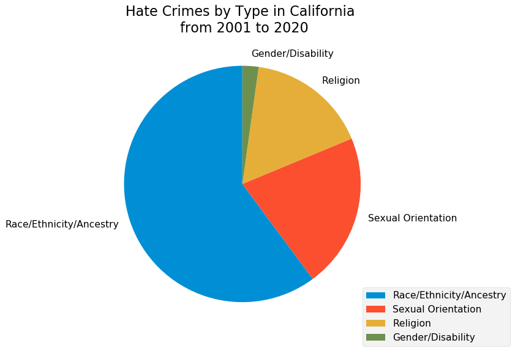

```python
# Create a pie chart visualizing the data
figure(figsize=(10, 8), dpi=80)
plt.pie(hate_by_type['Count'], labels=hate_by_type['Type'],
        startangle=90, textprops={'fontsize':14})
plt.legend(bbox_to_anchor=(0.75,0.25), loc="upper left",
          bbox_transform=plt.gcf().transFigure, fontsize=14)
plt.title("Hate Crimes by Type in California \n from 2001 to 2020", fontsize=20)
plt.show()
```

```python
# Group the crimes by year and type and find the number of crimes per year-type combination
hate_by_year_type = pd.DataFrame(hate_data.groupby(['ClosedYear', 'MostSeriousBiasType']).size())
hate_by_year_type = hate_by_year_type.reset_index()
hate_by_year_type = hate_by_year_type.set_axis(['Year', 'Type', 'Count'], axis=1, inplace=False)
hate_by_year_type.head()
```

|  | Year | Type | Count |
| --- | --- | --- | --- |
| 0 | 2001 | Disability | 4 |
| 1 | 2001 | Gender | 1 |
| 2 | 2001 | Gender Nonconforming | 14 |
| 3 | 2001 | Race/Ethnicity/Ancestry | 1526 |
| 4 | 2001 | Religion | 296 |

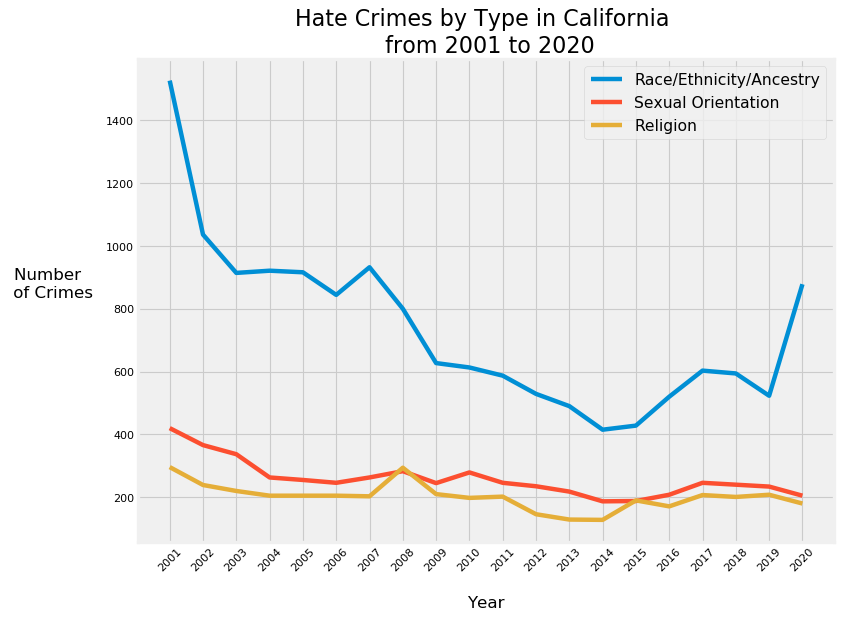

```python
# Plot the number of hate crimes per year for the three most common types
figure(figsize=(10, 8), dpi=80)
plt.plot(hate_by_year_type[hate_by_year_type['Type'] == 'Race/Ethnicity/Ancestry']['Year'],
         hate_by_year_type[hate_by_year_type['Type'] == 'Race/Ethnicity/Ancestry']['Count'],
         label='Race/Ethnicity/Ancestry')
plt.plot(hate_by_year_type[hate_by_year_type['Type'] == 'Sexual Orientation']['Year'],
         hate_by_year_type[hate_by_year_type['Type'] == 'Sexual Orientation']['Count'], label='Sexual Orientation')
plt.plot(hate_by_year_type[hate_by_year_type['Type'] == 'Religion']['Year'],
         hate_by_year_type[hate_by_year_type['Type'] == 'Religion']['Count'], label='Religion')
plt.title('Hate Crimes by Type in California \n from 2001 to 2020', fontsize=20)
plt.xlabel('Year', fontsize=15, labelpad=20)
plt.ylabel('Number \n of Crimes', fontsize=15, rotation=0, labelpad=50)
plt.xticks(rotation = 45)
plt.legend(prop={'size': 14})
plt.show()
```

## 2.4 Which racial and religious groups tend to be the most targeted?

Block 14 shows the number of hate crimes by race among the hate crimes motivated by a bias against race/ethnicity/ancestry in the data set. There are ten unique types. Among the crimes committed against a known race in a single marked category (i.e., excluding the third, sixth, and ninth rows in the data frame shown in Block 14), the crimes against black or African American individuals make up more than half of the racially motivated hate crimes (51.1%), followed by anti-Hispanic or Latino crimes (16.4%), anti-White crimes (7.9%), anti-Asian crimes (6.1%), anti-Arab crimes (2.4%), anti-American Indian or Alaska Native crimes (0.4%), and anti-Native Hawaiian or Pacific Islander crimes (0.1%).

To visualize these counts, a pie chart is created (Block 16). The crimes against unknown or multiple races or against races with relatively few crimes (American Indian/Alaska Native and Native Hawaiian/Pacific Islander) are combined into one category, called "Other" (Block 15).

The number of hate crimes against black or African American people dipped from 2001 to 2014 and rose from 2014 to 2020, thus reflecting the temporal pattern of all race/ethnicity/ancestry-related crimes in Block 13. Although the number of hate crimes against the other three races has remained relatively constant over this time period, crimes against all three showed an uptick from 2019 to 2020.

```python
# Group the "Race/Ethnicity/Ancestry" crimes by race and find the number of crimes of each race
hate_by_race = pd.DataFrame(hate_data[hate_data['MostSeriousBiasType'] == 'Race/Ethnicity/Ancestry'].groupby(['MostSeriousBias']).size())
hate_by_race = hate_by_race.reset_index()
hate_by_race = hate_by_race.set_axis(['Race', 'Count'], axis=1, inplace=False)
hate_by_race = hate_by_race.sort_values(by='Count', ascending=False).reset_index(drop=True)
hate_by_race['Proportion'] = round(hate_by_race['Count']/sum(hate_by_race['Count']), 3)
hate_by_race
```

|  | Race | Count | Proportion |
| --- | --- | --- | --- |
| 0 | Anti-Black or African American | 7508 | 0.511 |
| 1 | Anti-Hispanic or Latino | 2414 | 0.164 |
| 2 | Anti-Other Race/Ethnicity/Ancestry | 1559 | 0.106 |
| 3 | Anti-White | 1154 | 0.079 |
| 4 | Anti-Asian | 895 | 0.061 |
| 5 | Anti-Multiple Races (Group) | 697 | 0.047 |
| 6 | Anti-Arab | 355 | 0.024 |
| 7 | Anti-American Indian/Alaska Native | 52 | 0.004 |
| 8 | Anti-Citizenship Status | 50 | 0.003 |
| 9 | Anti-Native Hawaiian or Other Pacific Islander | 12 | 0.001 |

```python
# Combine the races with the lowest number of crimes into one category ("Other")
hate_by_race.loc[len(hate_by_race)] = ['Other', 1559+697+52+50+12,
                                      round((1559+697+52+50+12)/sum(hate_by_race['Count']), 3)]
hate_by_race = hate_by_race.drop([2, 5, 7, 8, 9]).reset_index(drop=True)
hate_by_race
```

|  | Race | Count | Proportion |
| --- | --- | --- | --- |
| 0 | Anti-Black or African American | 7508 | 0.511 |
| 1 | Anti-Hispanic or Latino | 2414 | 0.164 |
| 2 | Anti-White | 1154 | 0.079 |
| 3 | Anti-Asian | 895 | 0.061 |
| 4 | Anti-Arab | 355 | 0.024 |
| 5 | Other | 2370 | 0.161 |

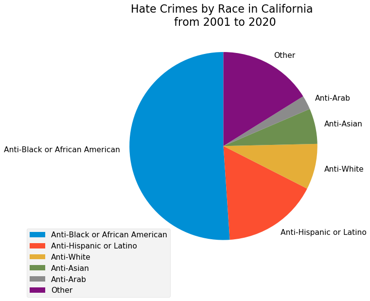

```python
# Create a pie chart visualizing the data
figure(figsize=(10, 8), dpi=80)
plt.pie(hate_by_race['Count'], labels=hate_by_race['Race'],
        startangle=90, textprops={'fontsize':14})
plt.legend(bbox_to_anchor=(0,0.25), loc="upper left",
          bbox_transform=plt.gcf().transFigure, fontsize=14)
plt.title("Hate Crimes by Race in California \n from 2001 to 2020", fontsize=20)
plt.show()
```

```python
# Group the crimes by year and race and find the number of crimes per year-race combination
hate_by_year_race = pd.DataFrame(hate_data[hate_data['MostSeriousBiasType'] == 'Race/Ethnicity/Ancestry'].groupby(['ClosedYear', 'MostSeriousBias']).size())
hate_by_year_race = hate_by_year_race.reset_index()
hate_by_year_race = hate_by_year_race.set_axis(['Year', 'Race', 'Count'], axis=1, inplace=False)
hate_by_year_race.head()
```

|  | Year | Race | Count |
| --- | --- | --- | --- |
| 0 | 2001 | Anti-American Indian/Alaska Native | 4 |
| 1 | 2001 | Anti-Asian | 93 |
| 2 | 2001 | Anti-Black or African American | 596 |
| 3 | 2001 | Anti-Hispanic or Latino | 206 |
| 4 | 2001 | Anti-Multiple Races (Group) | 71 |

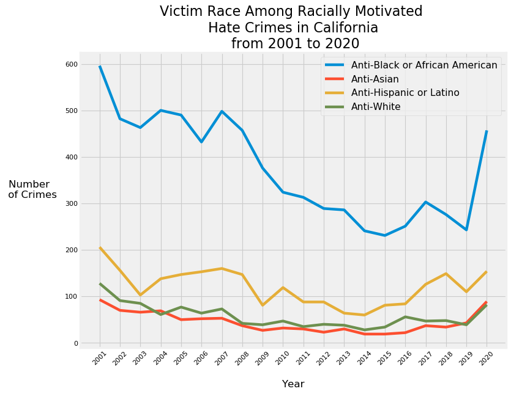

```python
# Plot the number of hate crimes per year for the four most common races
figure(figsize=(10, 8), dpi=80)
plt.plot(hate_by_year_race[hate_by_year_race['Race'] == 'Anti-Black or African American']['Year'],
         hate_by_year_race[hate_by_year_race['Race'] == 'Anti-Black or African American']['Count'], label='Anti-Black or African American')
plt.plot(hate_by_year_race[hate_by_year_race['Race'] == 'Anti-Asian']['Year'],
         hate_by_year_race[hate_by_year_race['Race'] == 'Anti-Asian']['Count'], label='Anti-Asian')
plt.plot(hate_by_year_race[hate_by_year_race['Race'] == 'Anti-Hispanic or Latino']['Year'],
         hate_by_year_race[hate_by_year_race['Race'] == 'Anti-Hispanic or Latino']['Count'], label='Anti-Hispanic or Latino')
plt.plot(hate_by_year_race[hate_by_year_race['Race'] == 'Anti-White']['Year'],
         hate_by_year_race[hate_by_year_race['Race'] == 'Anti-White']['Count'], label='Anti-White')
plt.title('Victim Race Among Racially Motivated \n Hate Crimes in California \n from 2001 to 2020', fontsize=20)
plt.xlabel('Year', fontsize=15, labelpad=20)
plt.ylabel('Number \n of Crimes', fontsize=15, rotation=0, labelpad=50)
plt.xticks(rotation = 45)
plt.legend(prop={'size': 14})
plt.show()
```

Block 19 shows the number of hate crimes by each religion among the hate crimes motivated by a bias against religion in the data set. There are fourteen unique types. Among the crimes committed against a known religion, the two most common types are those against Jewish people (63.5%) and Muslim people (12.1%).

To visualize these counts, a pie chart is created (Block 21). The crimes against Christian religions of different denominations are combined into one category called "Christian" for visualization purposes. The other religions ("Anti-Sikh", "Anti-Hindu", "Anti-Atheism-Agnosticism", and "Anti-Buddhist") are combined with the "Anti-Other Religion" and "Anti-Multiple Religions (Group)" categories to create a single category called "Other" (Block 20).

```python
# Group the "Religion" crimes by religion and find the number of crimes of each religion
hate_by_religion = pd.DataFrame(hate_data[hate_data['MostSeriousBiasType'] == 'Religion'].groupby(['MostSeriousBias']).size())
hate_by_religion = hate_by_religion.reset_index()
hate_by_religion = hate_by_religion.set_axis(['Religion', 'Count'], axis=1, inplace=False)
hate_by_religion = hate_by_religion.sort_values(by='Count', ascending=False).reset_index(drop=True)
hate_by_religion['Proprotion'] = round(hate_by_religion['Count']/sum(hate_by_religion['Count']), 3)
hate_by_religion
```

|  | Religion | Count | Proprotion |
| --- | --- | --- | --- |
| 0 | Anti-Jewish | 2563 | 0.635 |
| 1 | Anti-Islamic (Muslim) | 487 | 0.121 |
| 2 | Anti-Other Religion | 474 | 0.117 |
| 3 | Anti-Catholic | 189 | 0.047 |
| 4 | Anti-Multiple Religions (Group) | 131 | 0.032 |
| 5 | Anti-Protestant | 96 | 0.024 |
| 6 | Anti-Other Christian | 37 | 0.009 |
| 7 | Anti-Mormon | 13 | 0.003 |
| 8 | Anti-Sikh | 12 | 0.003 |
| 9 | Anti-Hindu | 10 | 0.002 |
| 10 | Anti-Atheism/Agnosticism | 9 | 0.002 |
| 11 | Anti-Buddhist | 8 | 0.002 |
| 12 | Anti-Eastern Orthodox (Russian/Greek/Other) | 4 | 0.001 |
| 13 | Anti-Jehovahs Witness | 4 | 0.001 |

```python
# Combine the Christian religions into one category and the rest into the "Other" category
hate_by_religion.loc[len(hate_by_religion)] = ['Anti-Christian', 189+96+37+13+4+4, (189+96+37+13+4+4)/sum(hate_by_religion['Count'])]
hate_by_religion.loc[len(hate_by_religion)] = ['Other', 474+131+12+10+9+8, (474+131+12+10+9+8)/sum(hate_by_religion['Count'])]
hate_by_religion = hate_by_religion.drop([2, 3, 4, 5, 6, 7, 8, 9, 10, 11, 12, 13]).reset_index(drop=True)
hate_by_religion
```

|  | Religion | Count | Proprotion |
| --- | --- | --- | --- |
| 0 | Anti-Jewish | 2563 | 0.635000 |
| 1 | Anti-Islamic (Muslim) | 487 | 0.121000 |
| 2 | Anti-Christian | 343 | 0.084964 |
| 3 | Other | 644 | 0.147032 |

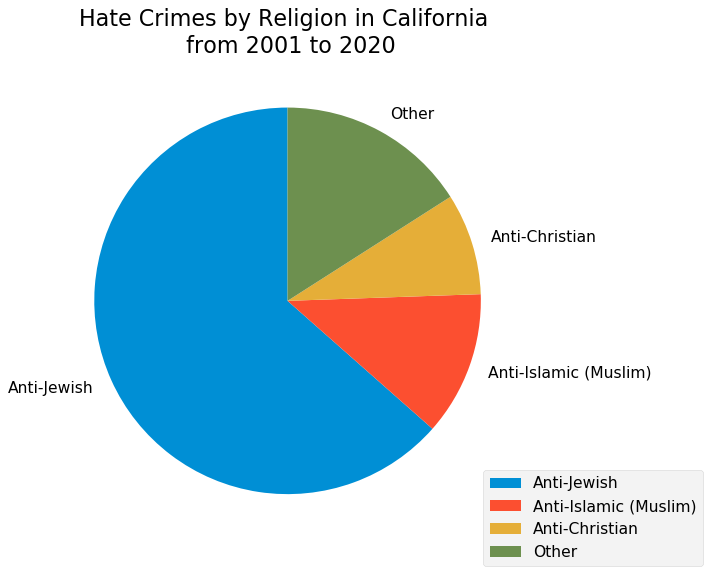

```python
# Create a pie chart visualizing the data
figure(figsize=(10, 8), dpi=80)
plt.pie(hate_by_religion['Count'], labels=hate_by_religion['Religion'],
        startangle=90, textprops={'fontsize':14})
plt.legend(bbox_to_anchor=(0.75,0.25), loc="upper left",
          bbox_transform=plt.gcf().transFigure, fontsize=14)
plt.title("Hate Crimes by Religion in California \n from 2001 to 2020", fontsize=20)
plt.show()
```

```python
# Group the crimes by year and religion and find the number of crimes per year-religion combination
hate_by_year_religion = pd.DataFrame(hate_data[hate_data['MostSeriousBiasType'] == 'Religion'].groupby(['ClosedYear', 'MostSeriousBias']).size())
hate_by_year_religion = hate_by_year_religion.reset_index()
hate_by_year_religion = hate_by_year_religion.set_axis(['Year', 'Religion', 'Count'], axis=1, inplace=False)
hate_by_year_religion.head()
```

|  | Year | Religion | Count |
| --- | --- | --- | --- |
| 0 | 2001 | Anti-Atheism/Agnosticism | 1 |
| 1 | 2001 | Anti-Catholic | 9 |
| 2 | 2001 | Anti-Islamic (Muslim) | 73 |
| 3 | 2001 | Anti-Jewish | 176 |
| 4 | 2001 | Anti-Multiple Religions (Group) | 14 |

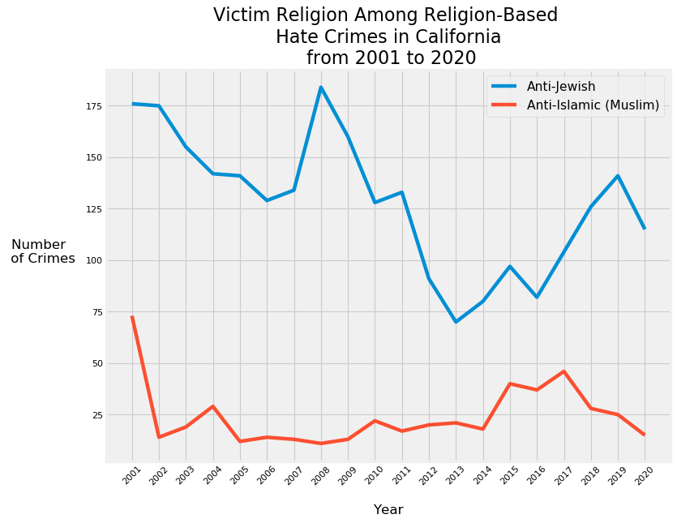

```python
# Plot the number of hate crimes per year for the two most common religions
figure(figsize=(10, 8), dpi=80)
plt.plot(hate_by_year_religion[hate_by_year_religion['Religion'] == 'Anti-Jewish']['Year'],
         hate_by_year_religion[hate_by_year_religion['Religion'] == 'Anti-Jewish']['Count'], label='Anti-Jewish')
plt.plot(hate_by_year_religion[hate_by_year_religion['Religion'] == 'Anti-Islamic (Muslim)']['Year'],
         hate_by_year_religion[hate_by_year_religion['Religion'] == 'Anti-Islamic (Muslim)']['Count'], label='Anti-Islamic (Muslim)')
plt.title('Victim Religion Among Religion-Based \n Hate Crimes in California \n from 2001 to 2020', fontsize=20)
plt.xlabel('Year', fontsize=15, labelpad=20)
plt.ylabel('Number \n of Crimes', fontsize=15, rotation=0, labelpad=50)
plt.xticks(rotation = 45)
plt.legend(prop={'size': 14})
plt.show()
```

# 3. Results: How is county political affiliation related to the geographical distribution of hate crimes?

In terms of the relationship between county political affiliation and the geographical distribution of hate crimes, our specific hypothesis is that counties with a higher proportion of registered Republican voters should have a greater number of hate crimes (relative to the population of each county). Given that negative attitudes towards minoritized social groups have been argued to be connected with the perpetration of hate crimes [6] and that Republicans tend to have more negative attitudes against minoritized social groups [7], it is possible that the distribution of hate crimes may be predicted by voter registration data.

This analysis is divided into two parts: (a) "Data Cleaning" and (b) "Analysis". The "Data Cleaning" section is further subdivided into the five steps that were taken to organize the data. The "Analysis" section contains the results. The relationship between county political affiliation and the geographical distribution of hate crimes is displayed for both 2008 and 2016 to illustrate the difference between the beginning of Obama's presidency and Trump's presidency.

## 3.1 Data Cleaning

**Step 1:** Create a data frame with the population of each county in California from 2001 to 2019.

Two data sets with information about the population of California counties were downloaded from the United States Census Bureau website [8]. The first had population data from 2001 to 2009 and the second contained population data from 2010 to 2019. Therefore, in order to create a data frame with the population of each county in California from 2001 to 2019, the two data sets had to be cleaned separately and then merged. Both data sets are organized such that each row refers to a unique county in California and each column after the first one refers to the population of the counties in a particular year (which is specified by the name of the column).

The data set with population data from 2001 to 2009 is shown in Block 24. In order to merge this data set with later blocks, the dot at the beginning of each value in the "County" column is removed in Block 25. The data set with population data from 2010 to 2019 is shown in Block 26, and the county names are adjusted to match the format of the prior data set in Block 27. In Block 28, the two population data sets are merged on the "County" column (only the column names are shown for brevity). Finally, Block 29 subsets the data for the years of interest: 2008 and 2016.

One of the goals of this section is to calculate the number of hate crimes per million people in each county, meaning that the number of hate crimes in each county has to be divided by the population of each county and multiplied by one million. In order to complete this calculation, the columns corresponding to the populations of each year have to be of the "int64" or "float64" type. However, all of the types of the columns are "object", as shown in Block 30. In order to change the types of the columns, the commas are first removed from all of the values corresponding to population numbers (Block 31) and then all of the columns are changed to the "int64" type (Block 32).

```python
# Load the county population data set for 2001 to 2009
pop_2000s = pd.read_csv("~/Desktop/co-est00int-01-06.csv").iloc[4:62,[0, 3, 4, 5, 6, 7, 8, 9, 10, 11]].reset_index(drop=True)
pop_2000s = pop_2000s.set_axis(['County', '2001', '2002', '2003', '2004',
                   '2005', '2006', '2007', '2008', '2009'], axis=1, inplace=False)
pop_2000s.head()
```

|  | County | 2001 | 2002 | 2003 | 2004 | 2005 | 2006 | 2007 | 2008 | 2009 |
| --- | --- | --- | --- | --- | --- | --- | --- | --- | --- | --- |
| 0 | .Alameda County | 1,469,484 | 1,462,106 | 1,454,163 | 1,445,721 | 1,441,545 | 1,444,484 | 1,455,715 | 1,477,208 | 1,498,539 |
| 1 | .Alpine County | 1,196 | 1,237 | 1,233 | 1,263 | 1,219 | 1,276 | 1,274 | 1,202 | 1,197 |
| 2 | .Amador County | 35,697 | 36,561 | 36,994 | 37,400 | 38,040 | 38,353 | 38,756 | 38,248 | 38,238 |
| 3 | .Butte County | 206,193 | 209,120 | 211,481 | 213,065 | 214,752 | 216,824 | 217,469 | 219,034 | 219,777 |
| 4 | .Calaveras County | 41,304 | 42,380 | 43,755 | 44,530 | 45,295 | 46,045 | 46,268 | 46,265 | 45,900 |

```python
# Remove the dots in front of each of the county names
for i in range(len(pop_2000s)):
    county_name = pop_2000s.iloc[i, 0]
    pop_2000s.iloc[i, 0] = county_name[1:]

pop_2000s['County'][0:5]
```

```
0      Alameda County
1       Alpine County
2       Amador County
3        Butte County
4    Calaveras County
Name: County, dtype: object
```

```python
# Load the county population data set for 2010 to 2019
pop_2010s = pd.read_csv("~/Desktop/co-est2019-annres-06.csv").iloc[4:62,[0, 3, 4, 5, 6, 7, 8, 9, 10, 11, 12]].reset_index(drop=True)
pop_2010s = pop_2010s.set_axis(['County', '2010', '2011', '2012', '2013', '2014',
                                '2015', '2016', '2017', '2018', '2019'], axis=1, inplace=False)
pop_2010s.head()
```

|  | County | 2010 | 2011 | 2012 | 2013 | 2014 | 2015 | 2016 | 2017 | 2018 | 2019 |
| --- | --- | --- | --- | --- | --- | --- | --- | --- | --- | --- | --- |
| 0 | .Alameda County, California | 1,512,986 | 1,530,915 | 1,553,764 | 1,579,593 | 1,607,792 | 1,634,538 | 1,650,950 | 1,660,196 | 1,666,756 | 1,671,329 |
| 1 | .Alpine County, California | 1,161 | 1,093 | 1,110 | 1,128 | 1,080 | 1,077 | 1,047 | 1,111 | 1,089 | 1,129 |
| 2 | .Amador County, California | 37,886 | 37,543 | 37,104 | 36,620 | 36,726 | 37,031 | 37,429 | 38,529 | 39,405 | 39,752 |
| 3 | .Butte County, California | 219,949 | 219,975 | 220,869 | 221,641 | 223,516 | 224,631 | 226,231 | 228,696 | 230,339 | 219,186 |
| 4 | .Calaveras County, California | 45,468 | 45,160 | 44,815 | 44,655 | 44,671 | 44,965 | 45,322 | 45,681 | 45,698 | 45,905 |

```python
# Adjust the county names in the data set
for i in range(len(pop_2010s)):
    county_name = pop_2010s.iloc[i, 0]
    county_name = county_name[1:]
    county_name = county_name[:-12]
    pop_2010s.iloc[i, 0] = county_name

pop_2010s['County'][0:5]
```

```
0      Alameda County
1       Alpine County
2       Amador County
3        Butte County
4    Calaveras County
Name: County, dtype: object
```

```python
# Merge the two population data sets
pop = pd.merge(pop_2000s, pop_2010s, on='County')
pop.columns
```

```
Index(['County', '2001', '2002', '2003', '2004', '2005', '2006', '2007',
       '2008', '2009', '2010', '2011', '2012', '2013', '2014', '2015', '2016',
       '2017', '2018', '2019'],
      dtype='object')
```

```python
# Only select the population columns corresponding to 2004, 2008, 2012, and 2016
pop = pop[['County', '2008', '2016']]
pop.head()
```

|  | County | 2008 | 2016 |
| --- | --- | --- | --- |
| 0 | Alameda County | 1,477,208 | 1,650,950 |
| 1 | Alpine County | 1,202 | 1,047 |
| 2 | Amador County | 38,248 | 37,429 |
| 3 | Butte County | 219,034 | 226,231 |
| 4 | Calaveras County | 46,265 | 45,322 |

```python
# Find the types of the columns
pop.dtypes
```

```
County    object
2008      object
2016      object
dtype: object
```

```python
# Eliminate all commas from the data set
pop = pop.replace(',', '', regex=True)
pop.head()
```

|  | County | 2008 | 2016 |
| --- | --- | --- | --- |
| 0 | Alameda County | 1477208 | 1650950 |
| 1 | Alpine County | 1202 | 1047 |
| 2 | Amador County | 38248 | 37429 |
| 3 | Butte County | 219034 | 226231 |
| 4 | Calaveras County | 46265 | 45322 |

```python
# Change the types of all the columns to integers
pop['2008'] = pop['2008'].astype(int)
pop['2016'] = pop['2016'].astype(int)
pop.dtypes
```

```
County    object
2008       int64
2016       int64
dtype: object
```

**Step 2:** Add metadata about the county code to the population data set.

This step is necessary because the hate crimes data set only contains the county code of the county where the hate crimes took place, not the name of the county itself, as in the population data set. Therefore, in order for the population data set and the hate crimes data set to be merged, county code information is needed in the population data set.

The first few rows of a data set with metadata about the counties is shown in Block 33. This data set was downloaded from the data portal of the State of California Department of Justice [4]. The county codes are added to the population data set in Block 34. Using the `.merge()` method was not necessary because the list of unique county codes, which was found with `list(set(county_metadata['CntyCode'])`, corresponds to the alphabetically ordered list of the counties, and the counties in the population data set also happen to be ordered alphabetically.

```python
# Load the data set with the county numbers
county_metadata = pd.read_csv("~/Desktop/NCIC_Code_Jurisdiction_List_06292021.csv")
county_metadata.head()
```

|  | CntyCode | County | Code | Agency | Start | End |
| --- | --- | --- | --- | --- | --- | --- |
| 0 | 1 | Alameda County | 0100 | Alameda Co. Sheriff's Department | NaN | NaN |
| 1 | 1 | Alameda County | 0101 | Alameda | NaN | NaN |
| 2 | 1 | Alameda County | 0102 | Albany | NaN | NaN |
| 3 | 1 | Alameda County | 0103 | Berkeley | NaN | NaN |
| 4 | 1 | Alameda County | 0104 | Emeryville | NaN | NaN |

```python
# Add the county codes to the merged population data set
pop['County_Number'] = list(set(county_metadata['CntyCode']))
pop.columns
```

```
Index(['County', '2008', '2016', 'County_Number'], dtype='object')
```

**Step 3:** Create a data set with the number of hate crimes in each county for the years 2008 and 2016.

Block 35 shows the total number of hate crimes per year for each county. Even from looking at the first few rows, one can see that certain counties are missing (e.g., there is no row corresponding to the year 2008 and the second county number). This is because there were no hate crimes for those particular combinations of year and county number (e.g., there were zero hate crimes in 2008 in the second county).

The code in Blocks 36 and 37 shows how these missing rows were added to the data set. Block 36 contains a list of the years of interest ("2008" and "2016") and the county numbers (1 to 58). The product of the years and county numbers if found and saved in a list. The `product()` is a "combinatoric iterator" from the `itertools` package that finds the Cartesian product of two lists (see the documentation [here](https://docs.python.org/3/library/itertools.html)). The Cartesian product of two lists represents every possible tuple such that the first element is from the first list and the second element is from the second list. In this case, the first four tuples would be ("2008", 1), ("2008", 2), ("2008", 3), and ("2008", 4). The total number of tuples in the Cartesian product equals the length of the first list multiplied by the length of the second list (here, 2 years * 58 county numbers = 116 tuples).

The code in Block 37 loops through each of the tuples in `year_numbers_combo`. If there is no row corresponding to a particular tuple, then a new row is created in `hate_by_county_year` with the year and county number of that tuple and a value of 0 for the `Count column`. This new row is then added as the last row of the data set. The last few rows of `hate_by_county_year` are shown in Block 37 after the for loop. As shown in Block 38, the number of rows equals 116, which is the same as the number of tuples (thus indicating that the for loop worked as expected).

Finally, the `hate_by_county_year` data set is merged with the population data set, `pop` on the `County_Number` column (Block 39). Each row in the new merged data set, `hate_by_county_year_pop`, corresponds to a unique county-year combination and contains the population on 2008 and 2016 as well as the county number and the number of hate crimes in each year for each county.

In Block 40, a separate data set called `hate_2008` is created by subsetting only the rows where the year equals 2008. The number of hate crimes in 2008 per one million people in each county is calculated in Block 41. The code in Block 42 does the same thing for the hate crimes in 2016.

```python
# Group the number of crimes by county and year
hate_by_county_year = pd.DataFrame(hate_data.groupby(['ClosedYear', 'County']).size()).reset_index()
hate_by_county_year = hate_by_county_year.set_axis(['Year', 'County_Number', 'Count'], axis=1, inplace=False)
hate_by_county_year = hate_by_county_year.loc[hate_by_county_year['Year'].isin(['2008', '2016'])]
hate_by_county_year.head()
```

|  | Year | County_Number | Count |
| --- | --- | --- | --- |
| 301 | 2008 | 1 | 52 |
| 302 | 2008 | 3 | 1 |
| 303 | 2008 | 4 | 6 |
| 304 | 2008 | 5 | 2 |
| 305 | 2008 | 6 | 1 |

```python
# Create a list of the unique years and the unique county numbers that should be in the data set
years = ['2008', '2016']
county_numbers = list(range(1, 59))

# Save the product of the years and county numbers as a list
year_numbers_combo = list(product(years, county_numbers))
```

```python
# Loop through each of the year-number combinations
for i in range(len(year_numbers_combo)):
    year = year_numbers_combo[i][0]
    number = year_numbers_combo[i][1]
    df_num_row = hate_by_county_year.loc[(hate_by_county_year['Year'] == year) & (hate_by_county_year['County_Number'] == number)].shape[0]

    # If there is no row corresponding to a year-number combination in hate_by_county_year...
    # ...then add a row with that combination and make the count equal to 0
    if df_num_row != 1:
        hate_by_county_year.loc[len(hate_by_county_year)] = [year, number, 0]

# Display the final few rows of the data set
hate_by_county_year.tail()
```

|  | Year | County_Number | Count |
| --- | --- | --- | --- |
| 111 | 2016 | 32 | 0 |
| 112 | 2016 | 46 | 0 |
| 113 | 2016 | 47 | 0 |
| 114 | 2016 | 52 | 0 |
| 115 | 2016 | 53 | 0 |

```python
# Find the number of rows and columns of the data set
hate_by_county_year.shape
```

```
(116, 3)
```

```python
# Merge the hate_by_county_year data set with the population data set
hate_by_county_year_pop = pd.merge(pop, hate_by_county_year, on='County_Number')
hate_by_county_year_pop.head()
```

|  | County | 2008 | 2016 | County_Number | Year | Count |
| --- | --- | --- | --- | --- | --- | --- |
| 0 | Alameda County | 1477208 | 1650950 | 1 | 2008 | 52 |
| 1 | Alameda County | 1477208 | 1650950 | 1 | 2016 | 59 |
| 2 | Alpine County | 1202 | 1047 | 2 | 2008 | 0 |
| 3 | Alpine County | 1202 | 1047 | 2 | 2016 | 0 |
| 4 | Amador County | 38248 | 37429 | 3 | 2008 | 1 |

```python
# Subset the data frame so that only the rows corresponding to the year 2008 are contained
hate_2008 = hate_by_county_year_pop[hate_by_county_year_pop['Year'] == '2008'].iloc[:,[0, 1, 3, 5]]
hate_2008.head()
```

|  | County | 2008 | County_Number | Count |
| --- | --- | --- | --- | --- |
| 0 | Alameda County | 1477208 | 1 | 52 |
| 2 | Alpine County | 1202 | 2 | 0 |
| 4 | Amador County | 38248 | 3 | 1 |
| 6 | Butte County | 219034 | 4 | 6 |
| 8 | Calaveras County | 46265 | 5 | 2 |

```python
# Find the relative proportion of hate crimes for each county in 2008
hate_2008['Prop_2008'] = hate_2008['Count']/hate_2008['2008'] * 1000000
hate_2008.head()
```

|  | County | 2008 | County_Number | Count | Prop_2008 |
| --- | --- | --- | --- | --- | --- |
| 0 | Alameda County | 1477208 | 1 | 52 | 35.201542 |
| 2 | Alpine County | 1202 | 2 | 0 | 0.000000 |
| 4 | Amador County | 38248 | 3 | 1 | 26.145158 |
| 6 | Butte County | 219034 | 4 | 6 | 27.393007 |
| 8 | Calaveras County | 46265 | 5 | 2 | 43.229223 |

```python
# Create a data frame similar to hate_2008 but for the 2016 hate crimes
hate_2016 = hate_by_county_year_pop[hate_by_county_year_pop['Year'] == '2016'].iloc[:,[0, 2, 3, 5]]
hate_2016['Prop_2016'] = hate_2016['Count']/hate_2016['2016'] * 1000000
```

**Step 4:** Find the proportion of registered Republican voters in each county for both 2008 and 2016.